# BCS70 Epigenetic data QC

G Shireby

## Introduction

This is an R Markdown document for the Quality Control (QC) of Illumina EPIC microarray data of the BCS70 (N= 255 samples) data.

Samples are not removed after each QC step, but a record is kept of samples which have already failed previous steps and the results of all tests are provided as output.

### Study Information

**Study:** BCS70

**Description:** BCS70 DNA methylation data

**Arrays ran by:** Kings College London

**Array used:** Illumina EPIC microarray v1.0

**QC done by:** Gemma Shireby, CLS, UCL

**Date of QC:** 22 September 2023

**Sample ages:** BCS70 (46 years)

**Sample tissue:** Whole blood

## Loading data

The phenotype file containing the sample information was loaded into R. Then the methylation data for the 255 samples were loaded into a methylumiset. This contains 255 BCS70 samples.

## Check Signal Intensities

The intensity check is the biggest indicator of sample quality. The median methylated signal intensity and unmethylated signal intensity for each sample is calculcated.

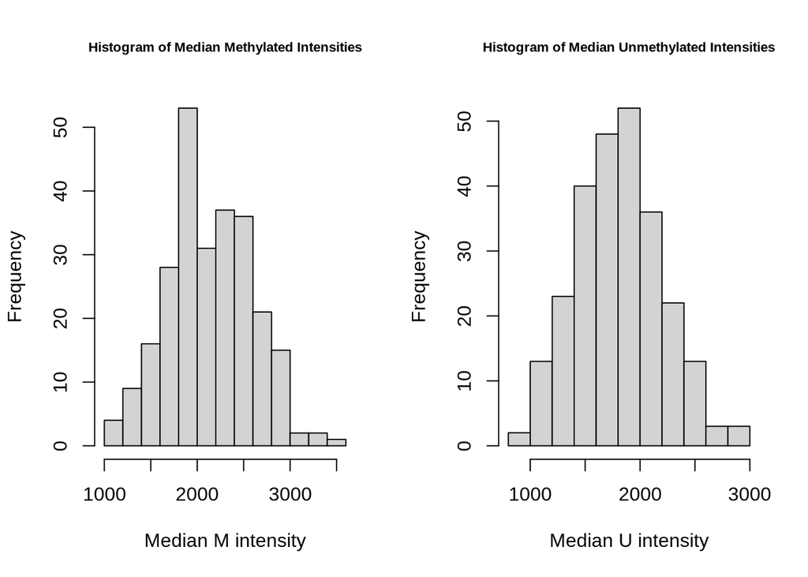

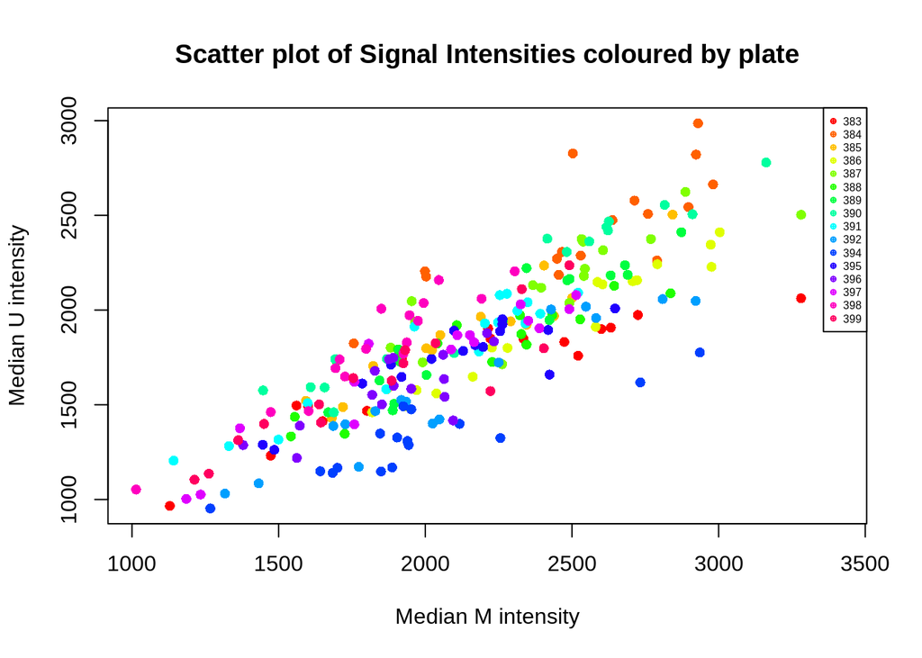

To further investigate the plates we can plot heatmaps of the intensities, shown below.

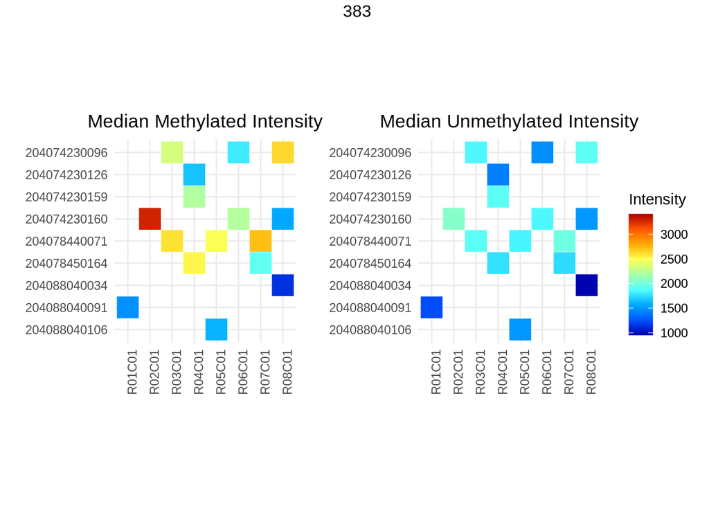

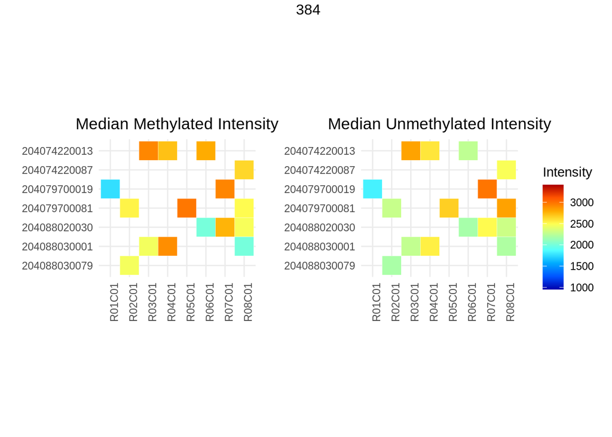

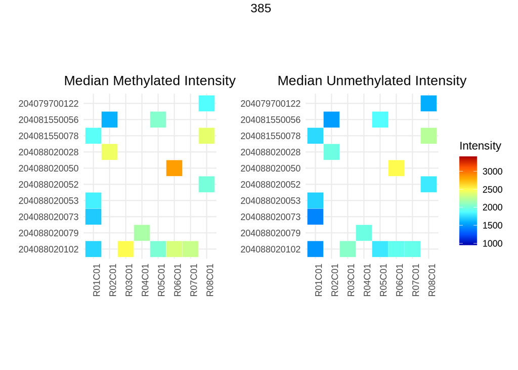

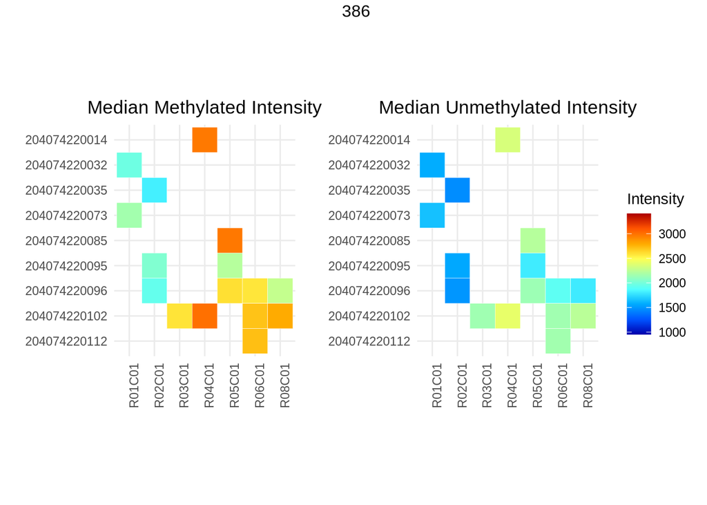

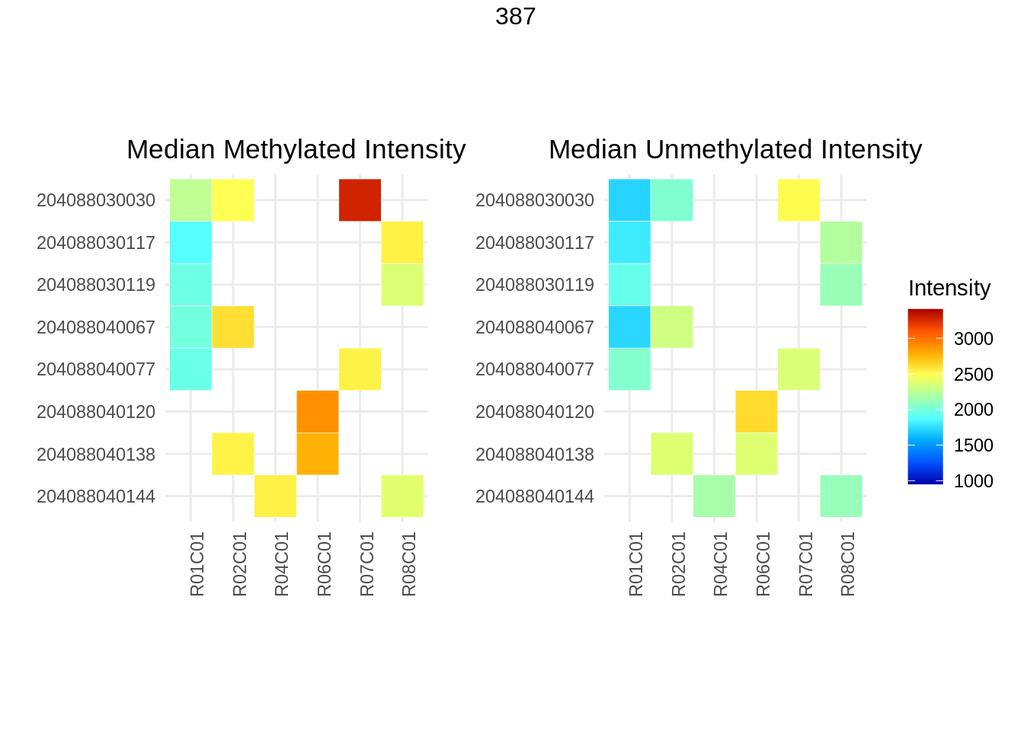

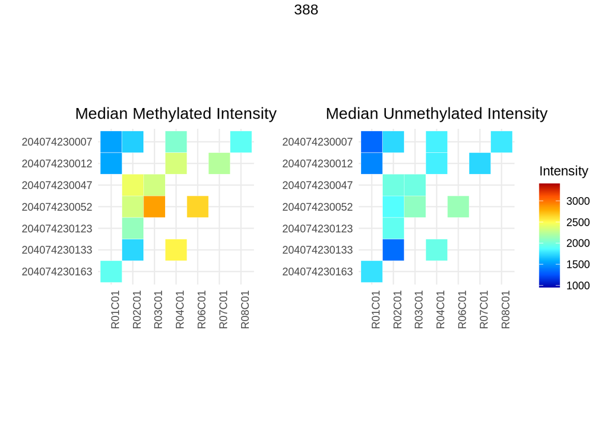

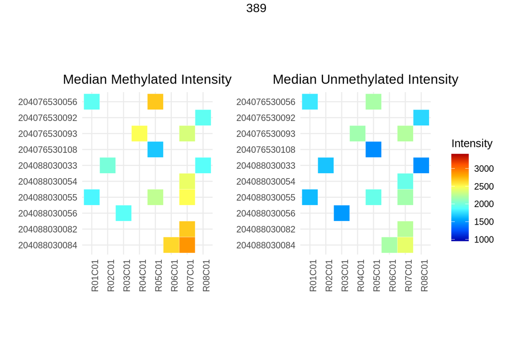

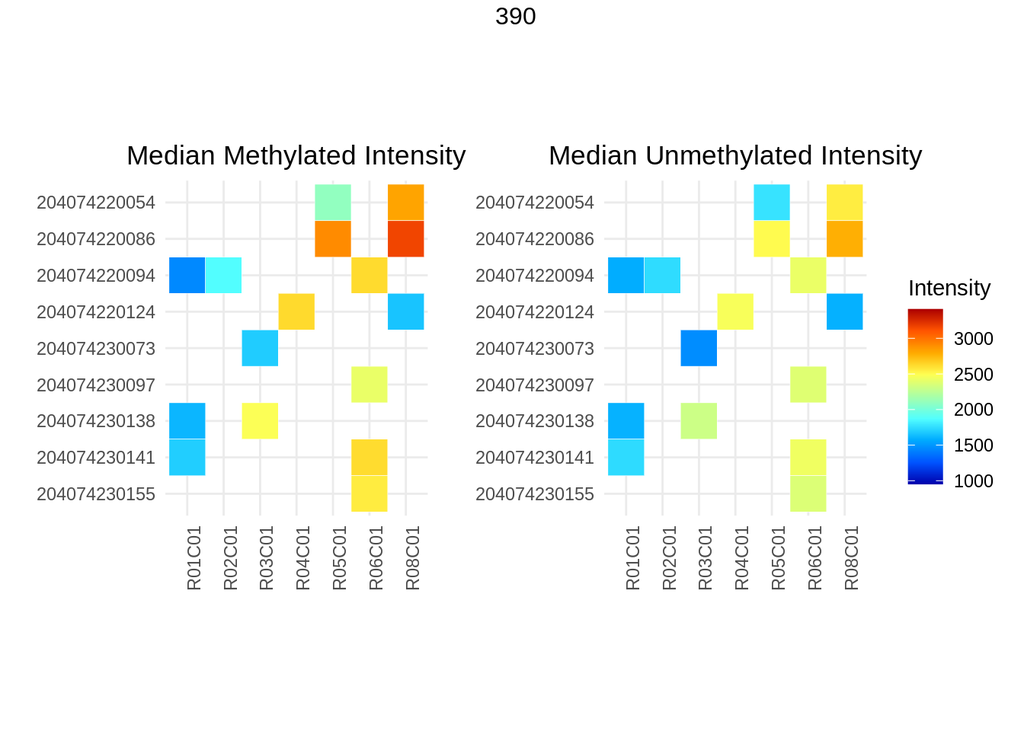

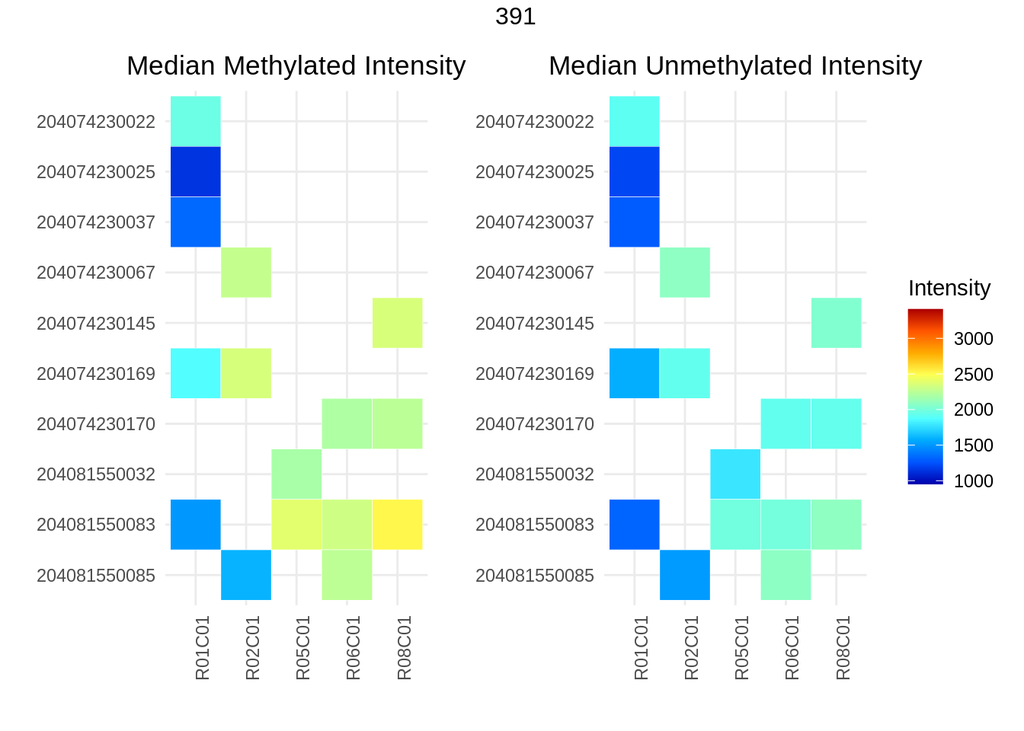

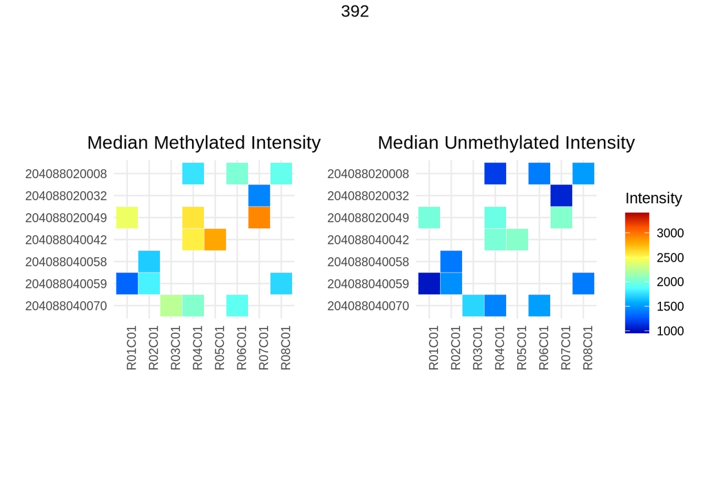

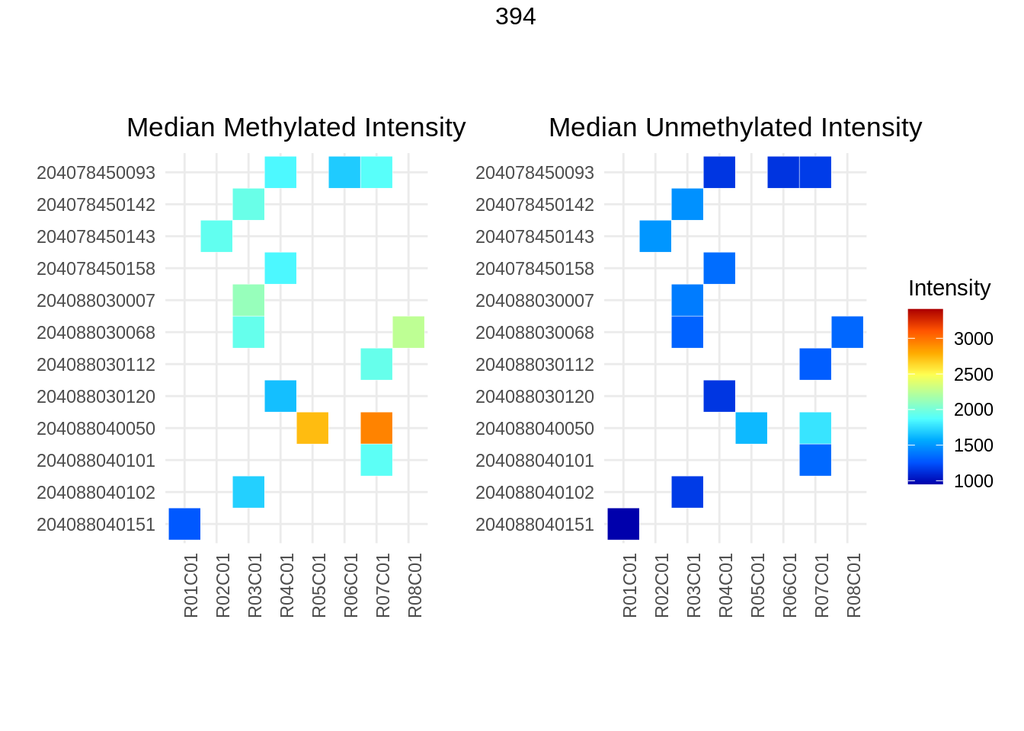

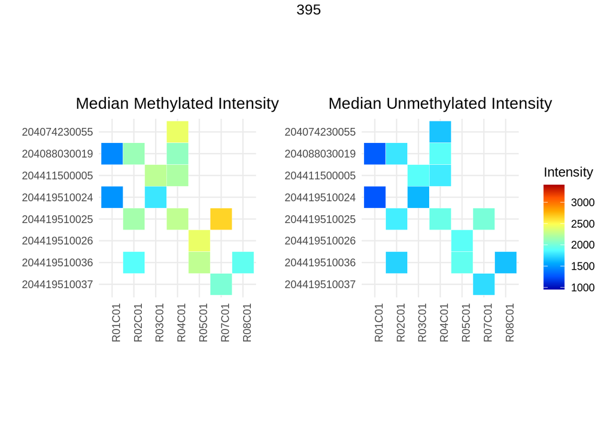

[4 more figures not shown]

We can see there are some differences in intensity across the plates (e.g. plate 384 has higher intensities than 394). Batch will need to be included as a covariate in future analysis.

Although signal intensity is the largest predictor of sample quality, the threshold at which to exclude samples can vary from experiment to experiment - for example, signal intensities can vary slightly depending on tissue type, extraction method etc... Samples which clearly deviate from the main cluster on the signal intensity plots should be removed. In this case we pick a threshold of 900. It is better to pick a more relaxed threshold as poorly performing samples will be removed at later steps.

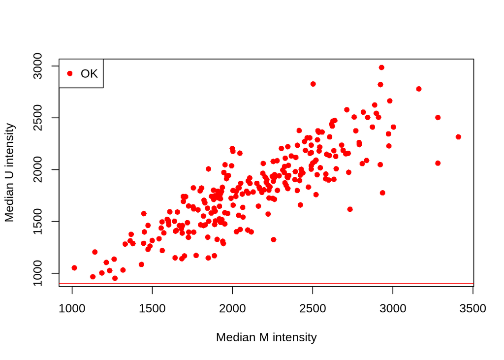

```r
print(Stepsummary)
```

```
##                  Step1
## Failed This Step     0
## Total Failed         0
```

## Bisulphite Conversion

A bisulphite conversion statistic for each sample was calculated, and a histogram of the results plotted.

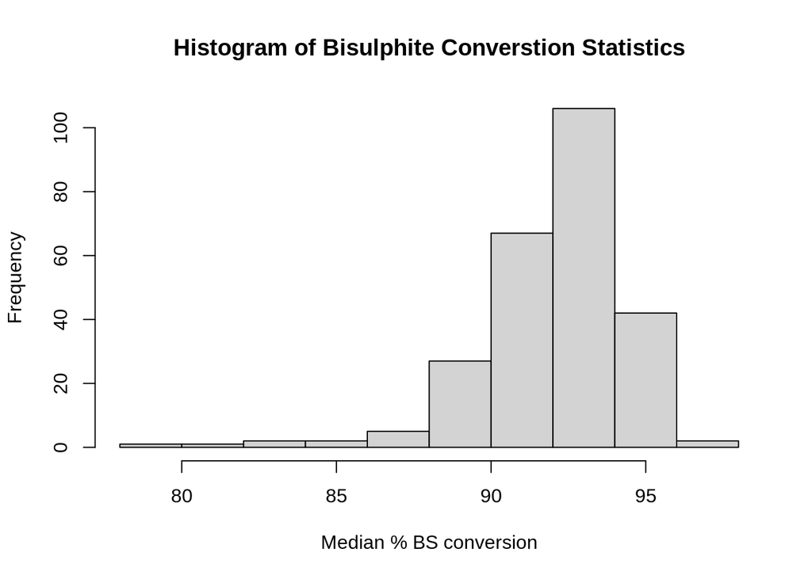

This shows the conversion statistics were generally high. Samples with a conversion < 80% fail the QC, so with this threshold 1 samples fail the QC, and will be removed at a later stage.

```r
print(Stepsummary)
```

```
##                  Step1 Step2
## Failed This Step     0     1
## Total Failed         0     1
```

## Check Sex

A principal component analysis of the methylation data can be used to predict the sex of the samples.

The principal components are calculated, and the two which correlate most with sex are found. These can be used to generate a scatter plot where the sexes are clearly separated.

```
## [1] "Top correlated principal components with sex: 3 , 4"
## [1] "Top PC has r > 0.9 with sex so good enough to confirm reported sexes"
```

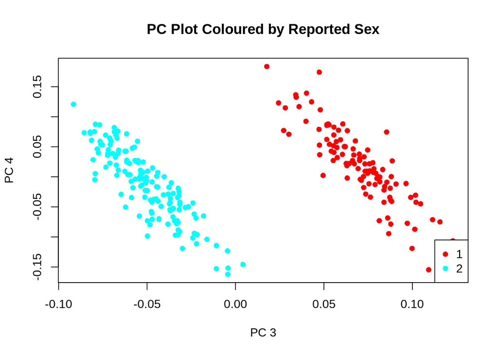

Just to check the clustering, we will also the run the ClusterGender.

```
## [1] "Top correlated principal components with sex: 3 , 4"
```

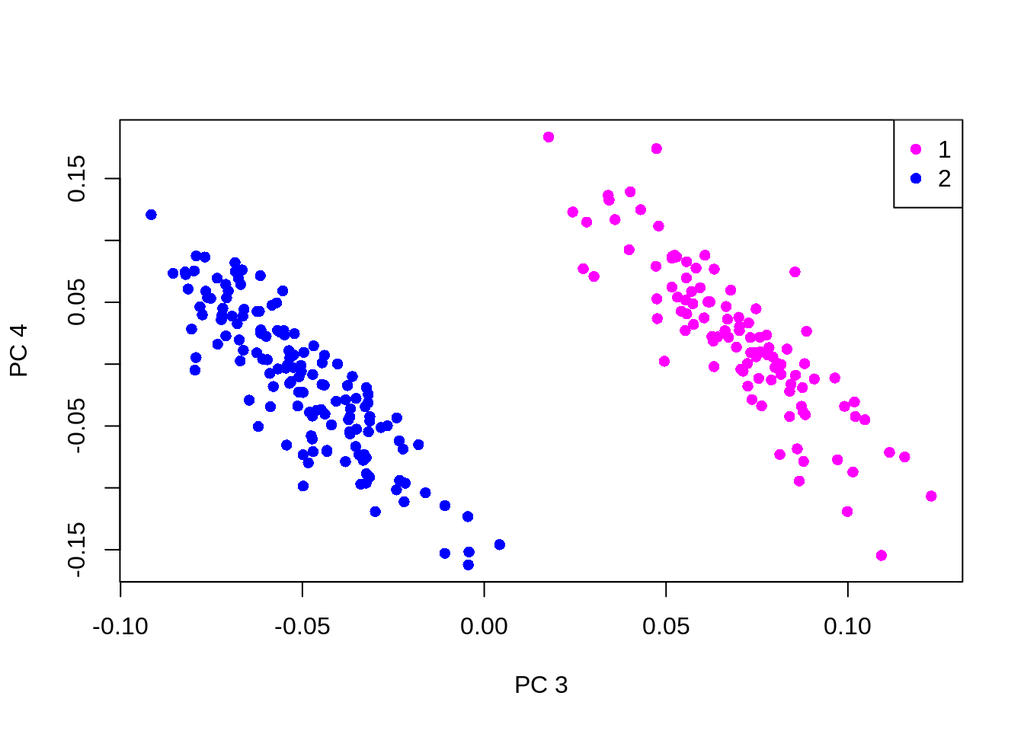

All samples are predicted the correct sex with both functions.

```r
print(Stepsummary)
```

```
##                  Step1 Step2 Step3
## Failed This Step     0     1     0
## Total Failed         0     1     1
```

## Check Genotypes

On the EPIC array there are 59 SNP probes. If we have genotyped data for these samples, we can compare the methylation on these SNP probes to the samples' genotypes to confirm samples are from the expected individual.

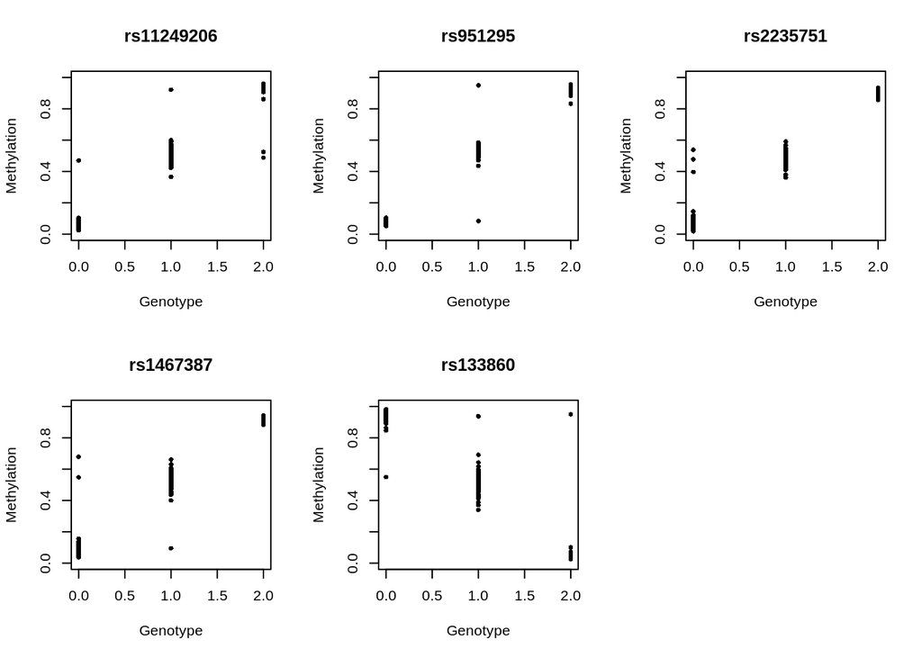

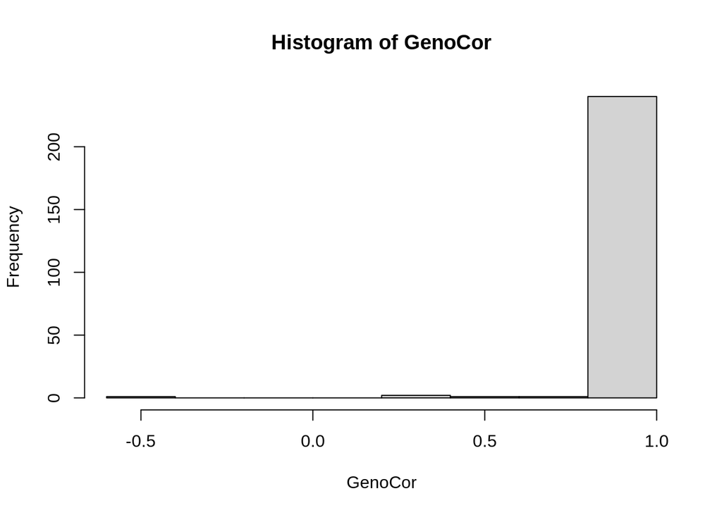

Of the 255 BCS70 samples, 7 do not have genotype information available.

Of the 248 which do, 5 have a correlation < 0.8 with their genotypes and fail the QC.

```r
print(Stepsummary)
```

```
##                  Step1 Step2 Step3 Step4
## Failed This Step     0     1     0     5
## Total Failed         0     1     1     6
```

## Genetic correlations

The 59 SNP probes on the array can also be used to estimate genetic correlations between samples.

This small number of probes means that only identical samples (such as samples from the same individual, MZ twins or samples duplicated by error) can be identified and no lower proportion of genetic relatedness (such as siblings) can be inferred (however this may now be done with the a new R package omicsPrint).

Since we expect all samples to be unrelated, all genetic correlations between samples should be low (approximately < 0.8). For each sample we can find the maximum correlation with any other sample, and plot a histogram of the results.

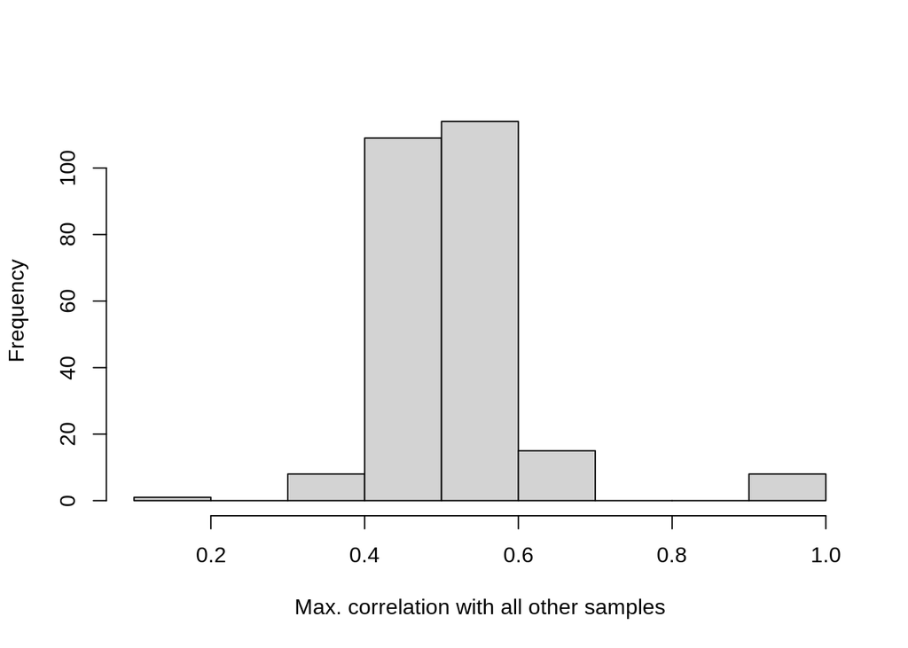

The histogram shows that 8 samples have a correlation > 0.8 with another sample. This suggests there are duplicates which we will remove.

```r
print(Stepsummary)
```

```
##                  Step1 Step2 Step3 Step4 Step5
## Failed This Step     0     1     0     5     8
## Total Failed         0     1     1     6    11
```

## Age Prediction

The age of samples can be predicted from their methylation data using Horvath's Coefficients and compared to the samples' reported ages.

However, this can be inaccurate and so it is used as a quality check and not as a reason to remove samples. Therefore, the following plot only contains samples which have passed the previous QC steps.

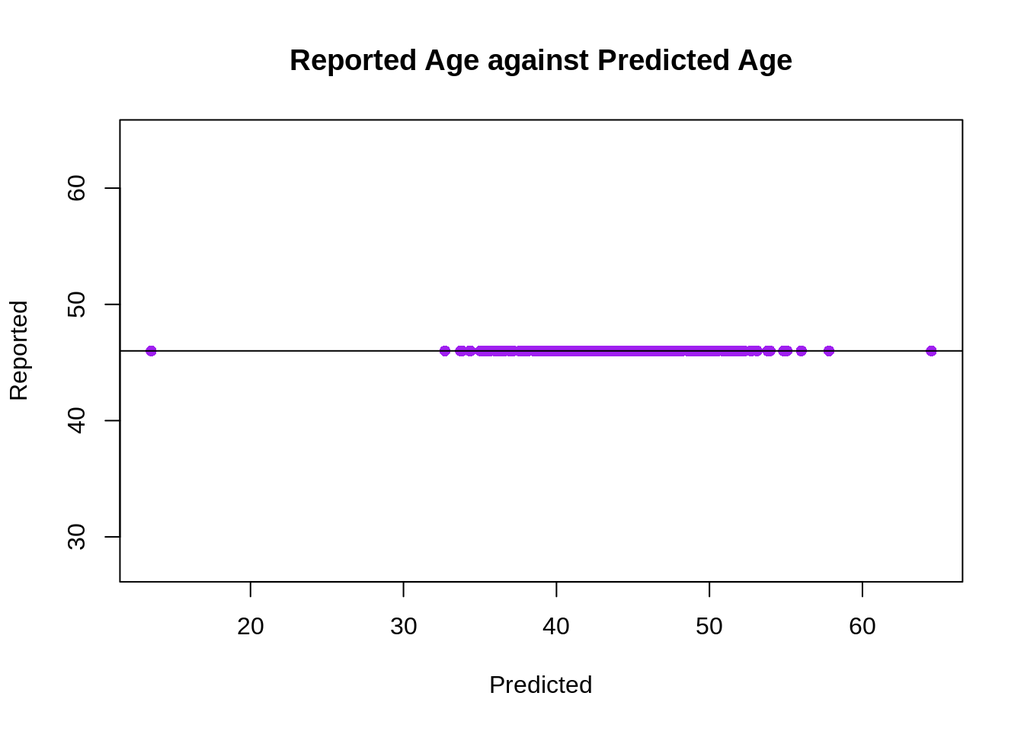

## Smoking Score

Smoking has well known associations with DNA methylation at sites across the genome. Using a method developed by Elliot et al. 2014 we can calculate a smoking score based on DNA methylation at these known sites, to predict smoking status.

A smoking score is calculated for each sample and a histogram of the scores is plotted below.

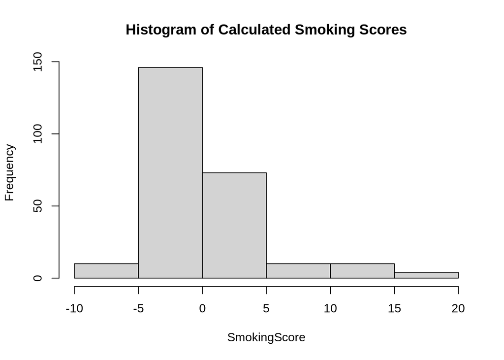

Smoking scores are added to the QC output and could be used as a covariate in later analyses if required or compared to samples reported smoking behaviours if provided.

## Cell Composition

DNA methylation varies between different cell types, and so the composition of cell types can significantly affect the methylation of samples. Therefore, estimations of cell-type composition is an important variable to consider when analysing this type of data.

Computational methods exist to estimate the cell-type composition of blood samples samples, using reference datasets of sorted samples. The function estimateCellCounts in the minfi package is used to estimate the composition of CD8 T-cells, CD4 T-cells, natural killer cells, B-cells, monocytes and granulocytes. Boxplots of the different cell proportions is plotted below.

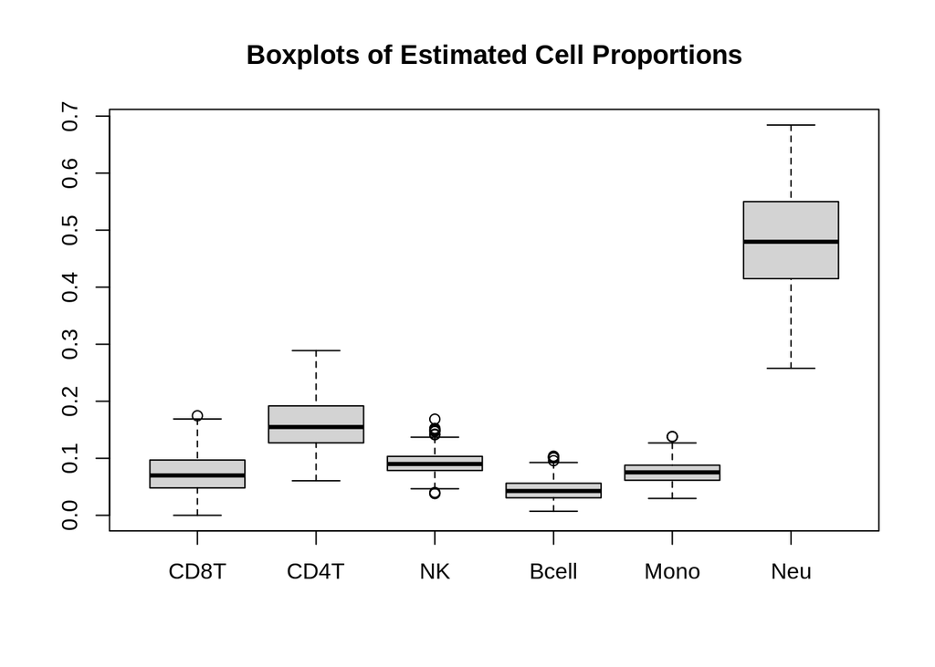

The estimated cell proportions are added to the QC output and can be used as covariates in later analyses.

## Pfilter

The pfilter function in the wateRmelon package filters data sets based on beadcounts and detection p-values.

### Beadcounts

If the percentage of samples with a beadcount less than 3 is greater than 5% for any probe, the probe is removed.

### Detection p-values

If the percentage of probes with a detection p-value less than 0.05 is greater than 1% for any sample, the sample is removed.

Similarly, if the percentage of samples with a detection p-value less than 0.05 is greater than 1% for any probe, the probe is removed.

```r
msetEPIC.pf <- pfilter(msetEPIC)
```

```
## 0 samples having 1 % of sites with a detection p-value greater than 0.05 were removed
## Samples removed:
## 2683 sites were removed as beadcount <3 in 5 % of samples
## 11877 sites having 1 % of samples with a detection p-value greater than 0.05 were removed
```

0 out of 255 samples fail the pfilter with these thresholds.

```r
print(Stepsummary)
```

```
##                  Step1 Step2 Step3 Step4 Step5 Step7
## Failed This Step     0     1     0     5     8     0
## Total Failed         0     1     1     6    11    11
```

## Outliers

The outlyx function in the wateRmelon package can be used to check if any of the remaining samples are classed as 'outliers' and should also be removed prior to normalisation.

```r
outliers <- outlyx(betas)
```

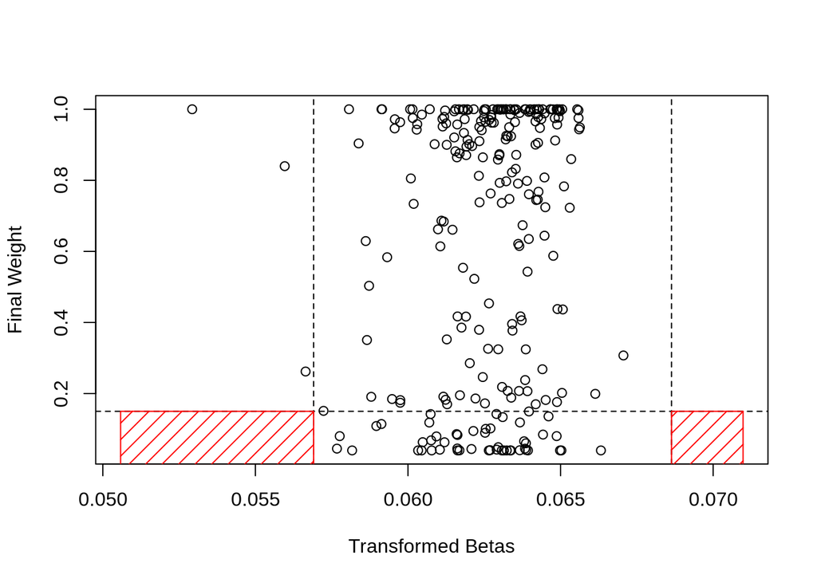

```r
print(Stepsummary)
```

```
##                  Step1 Step2 Step3 Step4 Step5 Step7
## Failed This Step     0     1     0     5     8     0
## Total Failed         0     1     1     6    11    11
```

No further samples have been picked as being outliers using the outlyx function providing reassurance that the QC pipeline has effectively removed failed samples.

## Normalisation

The methylation data for just the passed samples and probes is quantile normalised using the nasen function from the wateRmelon package. We originally tried dasen but this ended up with quirky data (some values > 1). We also inspected the negative control probes but nasen fixed the issues.

Density plots of the beta values are plotted for each sample before and after normalisation below (separated by type I and type II probes).

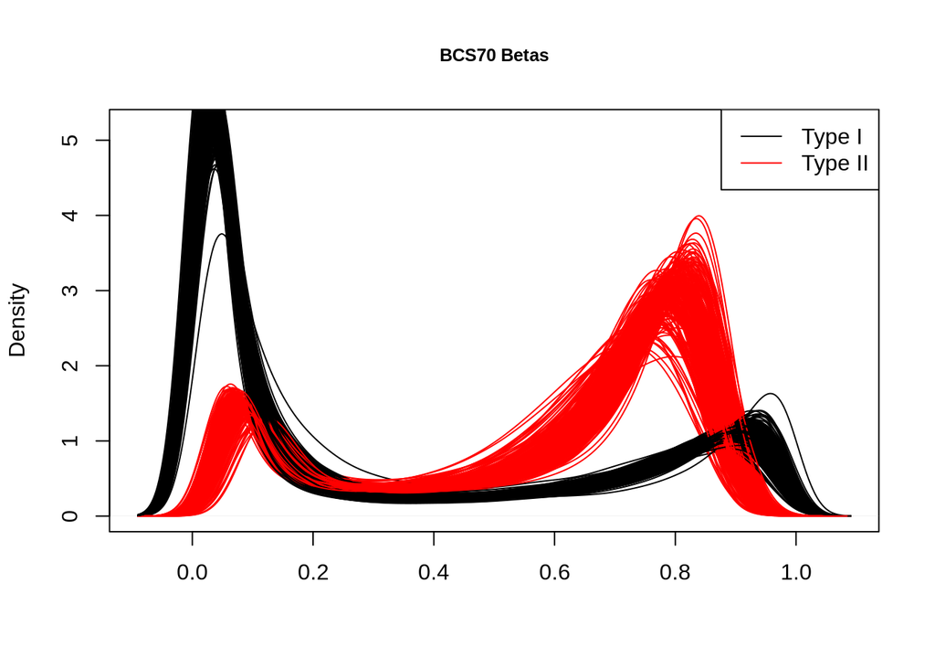

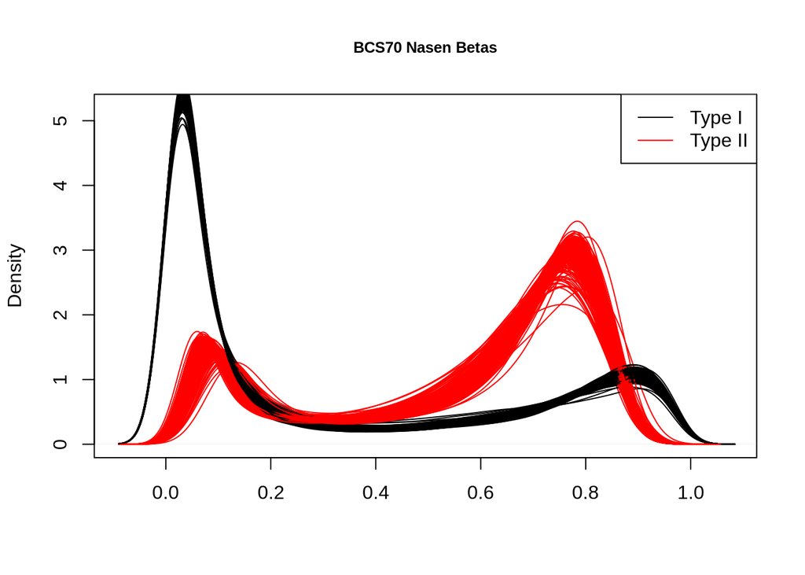

```
## [1] 0
```

```
## [1] "Max beta value"
```

```
## [1] 0.9946203
```

```
## [1] "Min beta value"
```

```
## [1] 3.720277e-06
```

The 'qual' function in the wateRmelon package can be used to assess the degree of difference between normalised and raw betas

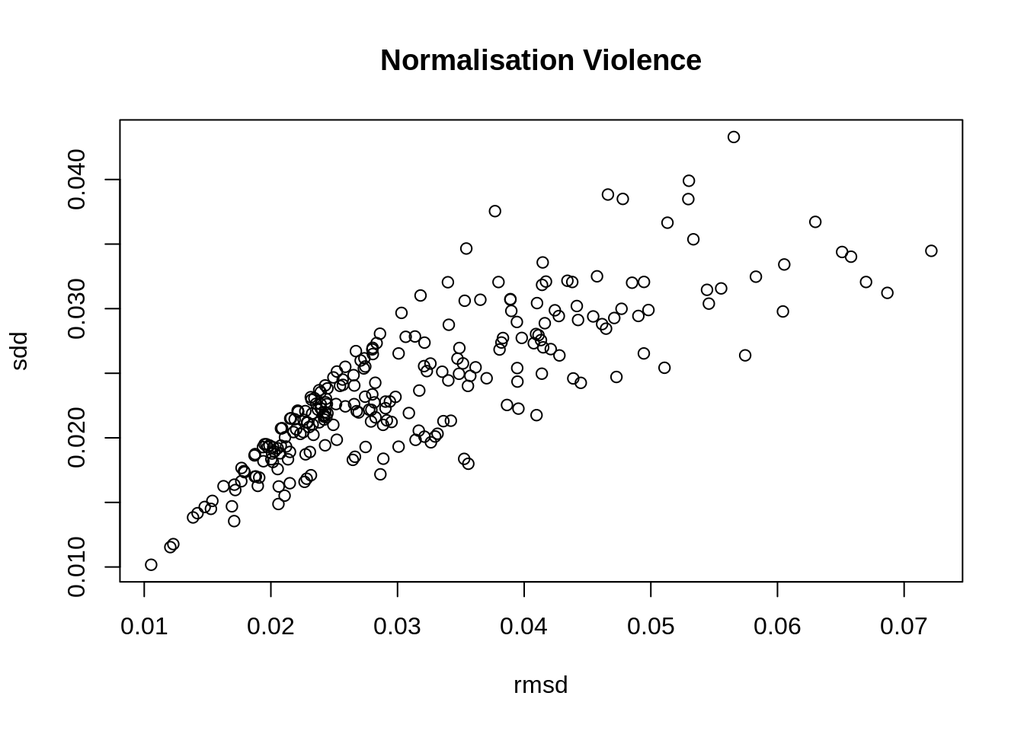

## QC Summary

The QC results for the 11 failed samples and 244 passed samples are saved to BCS70_SamplesFailedQC.csv and BCS70_SamplesPassedQC.csv respectively.

SNP probes, probes containing common SNPs, and probes with non-specific binding are removed at this stage to prevent technical artifacts influencing the results in later analyses.

Finally the QCed, normalised and filtered dataset is saved to BCS70_normalised.rdat ready for subsequent analysis.

The final dataset contains 244 samples and 799653 probes.